# 02 · El Radar: ¿dónde hay presión y dónde hay espacio?

**Torre del Caribe** · Fase 4 (A1 Radar) · Autor: **Brandon Uriel García Sánchez** · UNRC, LCDN 5° semestre 2026-2

[output not shown]

```python
%matplotlib inline
import sys, warnings
from pathlib import Path
warnings.filterwarnings("ignore")
RAIZ = Path.cwd().parent if Path.cwd().name == "notebooks" else Path.cwd()
sys.path.insert(0, str(RAIZ / "backend"))

import pandas as pd
import matplotlib.pyplot as plt
from torre.radar import panel as pn, indice as ix, prediccion as pr, markov as mk
from torre.documento.figuras import estilo_unrc, GUINDA, DORADO, GRIS_TEXTO, GRIS_SUAVE
pd.set_option("display.max_colwidth", 60)
estilo_unrc()
```

## 1. El panel mensual

Una fila por lugar y mes (enero de 2022 al último mes publicado): los 5 lugares y los destinos del resto del estado, que dan la escala común. Dos cuidados que se aprendieron al armarlo:

- Los visitantes a zonas arqueológicas se toman del INAH zona por zona: la serie de SITUR-Q es el mismo dato agrupado (Chetumal 2025 = Oxtankah + Kohunlich + Dzibanché = 39,459).
- La ocupación de SITUR-Q trae tres filas por mes (disponibles, ocupados y porcentaje): se recalcula como ocupados ÷ disponibles, nunca se suman ni se promedian porcentajes.

```python
panel = pn.panel_mensual()
print(f"{len(panel):,} filas · {panel.lugar.nunique()} lugares · {panel.periodo.min():%Y-%m} a {panel.periodo.max():%Y-%m}")
pn.cobertura(panel)[["meses_posibles", "llegadas_tren", "cruceristas", "cruces_belice", "visitantes_inah", "ocupacion_pct"]]
```

```
825 filas · 15 lugares · 2022-01 a 2026-07
```

| lugar | meses_posibles | llegadas_tren | cruceristas | cruces_belice | visitantes_inah | ocupacion_pct |
| --- | --- | --- | --- | --- | --- | --- |
| Chetumal | 55 | 20 | 0 | 54 | 0 | 36 |
| Bahía Calderitas–Oxtankah | 55 | 0 | 0 | 0 | 55 | 0 |
| Ruta arqueológica del sur | 55 | 0 | 0 | 0 | 55 | 0 |
| Maya Ka'an + Kantemó | 55 | 23 | 0 | 0 | 0 | 12 |
| Laguna Milagros–Xul-Ha | 55 | 0 | 0 | 0 | 0 | 0 |
| Bacalar | 55 | 20 | 0 | 0 | 55 | 12 |
| Cancún | 55 | 31 | 0 | 0 | 55 | 55 |
| Costa Mujeres | 55 | 0 | 0 | 0 | 55 | 36 |
| Cozumel | 55 | 0 | 55 | 0 | 55 | 55 |
| Holbox | 55 | 24 | 0 | 0 | 0 | 12 |
| Isla Mujeres | 55 | 0 | 0 | 0 | 0 | 55 |
| Mahahual | 55 | 0 | 55 | 0 | 0 | 12 |
| Playa del Carmen | 55 | 29 | 0 | 0 | 55 | 55 |
| Puerto Morelos | 55 | 29 | 0 | 0 | 0 | 36 |
| Tulum | 55 | 23 | 0 | 0 | 55 | 36 |

## 2. El índice de presión turística

$z=\dfrac{x-\min}{\max-\min}$ con mínimo y máximo de todo el estado; $IPT=$ promedio de las $z$ disponibles (pesos iguales). Un componente entra solo si lo tienen al menos 2 lugares (sale Belice, que solo tiene Chetumal).

```python
base, cortes, comps = ix.calcular()
print("Componentes del índice:", comps)
print(f"Cortes comunes: p50 = {cortes[0]:.3f}, p90 = {cortes[1]:.3f}")
cancun = base[(base.lugar == "Cancún") & (base.periodo == "2026-07-01")].iloc[0]
print("\nEjemplo a mano, Cancún jul-2026:")
for k in comps:
    if pd.notna(cancun[f"z_{k}"]):
        print(f"  {k:26s} x = {cancun[k]:10.4f}   z = {cancun[f'z_{k}']:.4f}")
print(f"  IPT = promedio = {cancun.ipt:.4f} → {cancun.estado}")
```

```
Componentes del índice:
```

```
 ['llegadas_tren_x1000hab', 'cruceristas_x1000hab', 'visitantes_inah_x1000hab', 'llegadas_x_cuarto', 'ocupacion_pct']
Cortes comunes: p50 = 0.258, p90 = 0.766

Ejemplo a mano, Cancún jul-2026:
  llegadas_tren_x1000hab     x =    25.1081   z = 0.0497
  visitantes_inah_x1000hab   x =     0.9608   z = 0.0001
  llegadas_x_cuarto          x =     0.4709   z = 0.0011
  ocupacion_pct              x =    68.7802   z = 0.7214
  IPT = promedio = 0.1931 → tranquilo
```

```python
# Sensibilidad: ¿cuántos lugar-mes cambian de estado si un peso se mueve ±50 %?
ix.sensibilidad(base, comps)
```

|  | componente | factor_peso | cambian_pct | cambian_5_lugares |
| --- | --- | --- | --- | --- |
| 0 | llegadas_tren_x1000hab | 0.5 | 3.1 | 0 |
| 1 | llegadas_tren_x1000hab | 1.5 | 1.7 | 0 |
| 2 | cruceristas_x1000hab | 0.5 | 2.0 | 0 |
| 3 | cruceristas_x1000hab | 1.5 | 0.6 | 0 |
| 4 | visitantes_inah_x1000hab | 0.5 | 3.1 | 1 |
| 5 | visitantes_inah_x1000hab | 1.5 | 2.3 | 1 |
| 6 | llegadas_x_cuarto | 0.5 | 3.1 | 4 |
| 7 | llegadas_x_cuarto | 1.5 | 2.0 | 0 |
| 8 | ocupacion_pct | 0.5 | 5.7 | 3 |
| 9 | ocupacion_pct | 1.5 | 6.0 | 5 |

**Prueba de validez.** La primera versión (solo SITUR-Q) calificaba a Cancún "tranquilo" en julio de 2026 porque SITUR-Q dejó de publicar ocupación en 2025; DataTur marca 68.8 %. Con la opción D (ocupación de DataTur para los 4 lugares que mide y sin componentes de un solo lugar), el norte queda arriba del sur en 2025–2026:

```python
m = base[base.periodo.dt.year >= 2025].groupby("lugar").ipt.mean().round(3)
m.drop(["Costa Mujeres", "Laguna Milagros–Xul-Ha"], errors="ignore").sort_values(ascending=False).to_frame("IPT promedio 2025–2026")
```

| lugar | IPT promedio 2025–2026 |
| --- | --- |
| Mahahual | 0.761 |
| Isla Mujeres | 0.434 |
| Bacalar | 0.319 |
| Tulum | 0.259 |
| Cancún | 0.206 |
| Cozumel | 0.198 |
| Playa del Carmen | 0.182 |
| Holbox | 0.168 |
| Ruta arqueológica del sur | 0.141 |
| Puerto Morelos | 0.045 |
| Chetumal | 0.028 |
| Bahía Calderitas–Oxtankah | 0.026 |
| Maya Ka'an + Kantemó | 0.009 |

## 3. El índice comparable (el que publica el Radar)

En 2025 los lugares que tenían la ocupación de SITUR-Q la pierden y su índice cae (Chetumal 0.54 → 0.05) sin que llegue menos gente. Por eso cada lugar se mide siempre con las mismas medidas, las que tiene hoy.

```python
t, cortes_c = pr.indice_comparable(base, comps)
print(f"Cortes del índice comparable: p50 = {cortes_c[0]:.3f}, p90 = {cortes_c[1]:.3f}")
t.dropna(subset=["ipt_comparable"]).groupby("lugar").agg(desde=("periodo", "min"), meses=("periodo", "size"), medidas=("medidas", "first"))
```

```
Cortes del índice comparable: p50 = 0.186, p90 = 0.756
```

| lugar | desde | meses | medidas |
| --- | --- | --- | --- |
| Bacalar | 2024-12-01 | 20 | llegadas_tren_x1000hab, visitantes_inah_x1000hab, llegad... |
| Bahía Calderitas–Oxtankah | 2022-01-01 | 55 | visitantes_inah_x1000hab |
| Cancún | 2024-01-01 | 31 | llegadas_tren_x1000hab, visitantes_inah_x1000hab, llegad... |
| Chetumal | 2024-12-01 | 20 | llegadas_tren_x1000hab, llegadas_x_cuarto |
| Costa Mujeres | 2022-01-01 | 36 | ocupacion_pct |
| Cozumel | 2022-01-01 | 55 | cruceristas_x1000hab, visitantes_inah_x1000hab, llegadas... |
| Holbox | 2024-08-01 | 24 | llegadas_tren_x1000hab, llegadas_x_cuarto |
| Isla Mujeres | 2022-01-01 | 55 | ocupacion_pct |
| Mahahual | 2022-01-01 | 55 | cruceristas_x1000hab, llegadas_x_cuarto |
| Maya Ka'an + Kantemó | 2024-09-01 | 23 | llegadas_tren_x1000hab, llegadas_x_cuarto |
| Playa del Carmen | 2024-03-01 | 29 | llegadas_tren_x1000hab, visitantes_inah_x1000hab, llegad... |
| Puerto Morelos | 2024-03-01 | 29 | llegadas_tren_x1000hab, llegadas_x_cuarto |
| Ruta arqueológica del sur | 2022-01-01 | 55 | visitantes_inah_x1000hab |
| Tulum | 2024-09-01 | 23 | llegadas_tren_x1000hab, visitantes_inah_x1000hab, llegad... |

[figure not shown]

```python
# Gráfica: el índice comparable de los 5 lugares contra la referencia del norte.
fig, ax = plt.subplots(figsize=(9, 4))
lugares = {"Chetumal": GUINDA, "Bahía Calderitas–Oxtankah": "#565393", "Ruta arqueológica del sur": "#58A65D",
           "Maya Ka'an + Kantemó": "#F26E50"}
referencia = {"Cancún": GRIS_TEXTO, "Tulum": GRIS_SUAVE}
for l, c in {**lugares, **referencia}.items():
    s = t[t.lugar == l].set_index("periodo").ipt_comparable.rolling(3, min_periods=1).mean()
    ax.plot(s.index, s.values, color=c, lw=2.4 if l in lugares else 1.6, ls="-" if l in lugares else "--",
            label=l if l in lugares else f"{l} (referencia)")
ax.axhspan(cortes_c[0], cortes_c[1], color=DORADO, alpha=.12, lw=0)
ax.axhspan(cortes_c[1], 1, color=GUINDA, alpha=.08, lw=0)
ax.text(t.periodo.min(), cortes_c[0] + .01, "concurrido", fontsize=8.5, color=GRIS_TEXTO)
ax.text(t.periodo.min(), cortes_c[1] + .01, "saturado", fontsize=8.5, color=GRIS_TEXTO)
ax.set_ylim(0, 1); ax.set_ylabel("Índice de presión (0 a 1)")
ax.set_title("Los cinco lugares se mantienen en la franja tranquila")
ax.legend(frameon=False, fontsize=8, ncol=2, loc="upper left")
fig.text(0.01, -0.03, "Promedio móvil de 3 meses. Fuentes: SITUR-Q, INAH, SECTUR-DataTur, Censo 2020. "
         "Cálculo: backend/torre/radar", fontsize=7.5, color=GRIS_TEXTO)
fig.savefig(RAIZ / "docs" / "ejecutivo" / "figuras" / "f08_radar.png")
plt.show()
```

## 4. ¿Se puede anticipar el mes siguiente?

Tres modelos contra la **persistencia** ("el mes que viene igual que este"), con backtesting de origen móvil: para cada uno de los últimos 12 meses se reentrena con todo lo anterior y se predice ese mes.

```python
r = pr.correr()
r["metricas"][["modelo", "aciertos", "casos", "cambios_reales", "cambios_acertados", "falsas_alarmas", "f1_macro_origen_movil"]]
```

|  | modelo | aciertos | casos | cambios_reales | cambios_acertados | falsas_alarmas | f1_macro_origen_movil |
| --- | --- | --- | --- | --- | --- | --- | --- |
| 0 | Persistencia (línea base) | 126 | 156 | 30 | 0 | 0 | 0.774 |
| 1 | Regresión logística | 130 | 156 | 30 | 8 | 4 | 0.793 |
| 2 | Random Forest | 130 | 156 | 30 | 6 | 2 | 0.766 |
| 3 | Gradient Boosting | 128 | 156 | 30 | 7 | 5 | 0.731 |

**Lectura honesta:** el estado se repite ocho de cada diez meses, así que la persistencia ya acierta mucho. El criterio de Brandon elige el modelo que más acierta y, a igualdad, el que más cambios anticipa (tras la auditoría, la regresión logística: 130 de 156 y 8 de 30 cambios).

**Sesgo** (punto del plan): el mismo backtest separado entre los 5 lugares y el resto del estado.

```python
print("Modelo elegido:", r["mejor"])
r["sesgo"]
```

```
Modelo elegido: Regresión logística
```

|  | grupo | casos | exactitud_modelo | exactitud_persistencia | cambios_reales | cambios_acertados | falsas_alarmas |
| --- | --- | --- | --- | --- | --- | --- | --- |
| 0 | resto del estado | 108 | 0.778 | 0.741 | 28 | 8 | 4 |
| 1 | 5 lugares | 48 | 0.958 | 0.958 | 2 | 0 | 0 |

Los 5 lugares casi no cambiaron de estado en la prueba: el modelo no se puede validar ahí. Predicción para el mes siguiente (estimada):

```python
r["prediccion"][["lugar", "estado_hoy", "estado_mes_siguiente_est", "prob_tranquilo", "prob_concurrido", "prob_saturado"]].round(2)
```

|  | lugar | estado_hoy | estado_mes_siguiente_est | prob_tranquilo | prob_concurrido | prob_saturado |
| --- | --- | --- | --- | --- | --- | --- |
| 0 | Bacalar | concurrido | concurrido | 0.20 | 0.80 | 0.0 |
| 1 | Bahía Calderitas–Oxtankah | tranquilo | tranquilo | 1.00 | 0.00 | 0.0 |
| 2 | Cancún | concurrido | tranquilo | 0.63 | 0.37 | 0.0 |
| 3 | Chetumal | tranquilo | tranquilo | 1.00 | 0.00 | 0.0 |
| 4 | Cozumel | concurrido | tranquilo | 0.68 | 0.32 | 0.0 |
| 5 | Holbox | concurrido | tranquilo | 0.58 | 0.42 | 0.0 |
| 6 | Isla Mujeres | concurrido | concurrido | 0.10 | 0.90 | 0.0 |
| 7 | Mahahual | concurrido | concurrido | 0.00 | 0.60 | 0.4 |
| 8 | Maya Ka'an + Kantemó | tranquilo | tranquilo | 1.00 | 0.00 | 0.0 |
| 9 | Playa del Carmen | tranquilo | tranquilo | 0.77 | 0.23 | 0.0 |
| 10 | Puerto Morelos | tranquilo | tranquilo | 0.96 | 0.04 | 0.0 |
| 11 | Ruta arqueológica del sur | tranquilo | tranquilo | 0.98 | 0.02 | 0.0 |
| 12 | Tulum | tranquilo | tranquilo | 0.81 | 0.19 | 0.0 |

## 5. Cadena de Markov semanal del norte

Estados por percentiles comunes de la ocupación semanal de los 7 centros de DataTur; $\hat p_{ij}=n_{ij}/\sum_j n_{ij}$ y $\pi_{t+k}=\pi_tP^k$.

```python
mkv = mk.correr()
print(f"Cortes: p50 = {mkv['cortes'][0]:.1f} %, p90 = {mkv['cortes'][1]:.1f} % · transiciones: {int(mkv['n'].to_numpy().sum()):,}")
mkv["P"].round(3)
```

```
Cortes: p50 = 71.2 %, p90 = 85.9 % · transiciones: 1,666
```

| hacia desde | tranquilo | concurrido | saturado |
| --- | --- | --- | --- |
| tranquilo | 0.922 | 0.078 | 0.000 |
| concurrido | 0.100 | 0.831 | 0.069 |
| saturado | 0.012 | 0.262 | 0.726 |

```python
print("Largo plazo (π = πP):", mkv["pi"].round(3).to_dict())
mkv["backtest"]
```

```
Largo plazo (π = πP): {'tranquilo': 0.513, 'concurrido': 0.389, 'saturado': 0.098}
```

|  | k_semanas | metodo | brier | exactitud | casos |
| --- | --- | --- | --- | --- | --- |
| 0 | 1 | Markov | 0.200 | 0.887 | 364 |
| 1 | 1 | Persistencia | 0.225 | 0.887 | 364 |
| 2 | 1 | Frecuencia simple | 0.544 | 0.629 | 364 |
| 3 | 4 | Markov | 0.389 | 0.723 | 364 |
| 4 | 4 | Persistencia | 0.484 | 0.758 | 364 |
| 5 | 4 | Frecuencia simple | 0.549 | 0.629 | 364 |
| 6 | 8 | Markov | 0.490 | 0.632 | 364 |
| 7 | 8 | Persistencia | 0.676 | 0.662 | 364 |
| 8 | 8 | Frecuencia simple | 0.555 | 0.629 | 364 |

```python
mkv["riesgo"].round(3)
```

|  | estado_hoy | ocupacion_hoy_pct | sem_1 | sem_2 | sem_3 | sem_4 | sem_5 | sem_6 | sem_7 | sem_8 |
| --- | --- | --- | --- | --- | --- | --- | --- | --- | --- | --- |
| Akumal | tranquilo | 34.4 | 0.000 | 0.005 | 0.013 | 0.022 | 0.031 | 0.040 | 0.047 | 0.054 |
| Cancun | tranquilo | 67.5 | 0.000 | 0.005 | 0.013 | 0.022 | 0.031 | 0.040 | 0.047 | 0.054 |
| Cozumel | tranquilo | 56.2 | 0.000 | 0.005 | 0.013 | 0.022 | 0.031 | 0.040 | 0.047 | 0.054 |
| Isla Mujeres | tranquilo | 48.1 | 0.000 | 0.005 | 0.013 | 0.022 | 0.031 | 0.040 | 0.047 | 0.054 |
| Playa Del Carmen | tranquilo | 63.9 | 0.000 | 0.005 | 0.013 | 0.022 | 0.031 | 0.040 | 0.047 | 0.054 |
| Playacar | concurrido | 81.7 | 0.069 | 0.107 | 0.127 | 0.136 | 0.139 | 0.138 | 0.135 | 0.132 |
| Riviera Maya | tranquilo | 62.1 | 0.000 | 0.005 | 0.013 | 0.022 | 0.031 | 0.040 | 0.047 | 0.054 |

## 6. Minería: el norte comparado con los centros turísticos del país

Clustering jerárquico (Ward) de los centros de DataTur con sus 55 meses completos, por su perfil de ocupación de 12 meses. El número de grupos se elige con la silueta (decisión de Brandon).

```python
from torre.radar import clustering as cl
from scipy.cluster.hierarchy import dendrogram
cls = cl.correr()
print(f"Centros completos: {len(cls['perfiles'])} · excluidos: {len(cls['excluidos'])}")
print("Silueta por k:", {k: round(v, 3) for k, v in cls["siluetas"].items()}, "→ k =", cls["k"])
cls["tabla"]
```

```
Centros completos: 55 · excluidos: 41
Silueta por k: {2: 0.45, 3: 0.38, 4: 0.365, 5: 0.3, 6: 0.283, 7: 0.317, 8: 0.306} → k = 2
```

| grupo | centros | nivel_medio | amplitud_media | mes_pico_mas_comun | ejemplos |
| --- | --- | --- | --- | --- | --- |
| 1 | 23 | 64.5 | 19.9 | nov | Playacar, Akumal, Cancun, Riviera Maya, Los Cabos |
| 2 | 32 | 41.1 | 17.6 | nov | Morelia, Cozumel, Oaxaca, San Luis Potosi, Guadalajara |

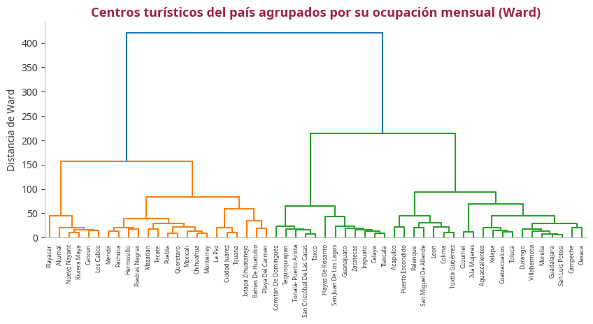

```python
fig, ax = plt.subplots(figsize=(10, 4))
dendrogram(cls["Z"], labels=list(cls["perfiles"].index), leaf_font_size=6, color_threshold=cls["Z"][-cls["k"] + 1, 2], ax=ax)
ax.set_title("Centros turísticos del país agrupados por su ocupación mensual (Ward)")
ax.set_ylabel("Distancia de Ward")
plt.show()
```